# balance Quickstart: Analyzing and adjusting the bias on a simulated toy dataset

'balance' is a Python package that is maintained and released by the Core Data Science Tel-Aviv team in Meta. 'balance' performs and evaluates bias reduction by weighting for a broad set of experimental and observational use cases.

Although balance is written in Python, you don't need a deep Python understanding to use it. In fact, you can just use this notebook, load your data, change some variables and re-run the notebook and produce your own weights!

This quickstart demonstrates re-weighting specific simulated data, but if you have a different usecase or want more comprehensive documentation, you can check out the comprehensive balance tutorial.

## Analysis

There are four main steps to analysis with balance:

- load data
- check diagnostics before adjustment
- perform adjustment + check diagnostics
- output results

Let's dive right in!

## Example dataset

The following is a toy simulated dataset.

```python
%matplotlib inline

import plotly.offline as offline
offline.init_notebook_mode()

import warnings
warnings.filterwarnings("ignore")

from balance import load_data
```

```
INFO (2026-05-22 10:26:10,445) [__init__/<module> (line 76)]: Using balance version 0.20.0
```

[output not shown]

```python
target_df, sample_df = load_data()

print("target_df: \n", target_df.head())
print("sample_df: \n", sample_df.head())
```

```
target_df:
        id gender age_group     income  happiness
0  100000   Male       45+  10.183951  61.706333
1  100001   Male       45+   6.036858  79.123670
2  100002   Male     35-44   5.226629  44.206949
3  100003    NaN       45+   5.752147  83.985716
4  100004    NaN     25-34   4.837484  49.339713
sample_df:
   id  gender age_group     income  happiness
0  0    Male     25-34   6.428659  26.043029
1  1  Female     18-24   9.940280  66.885485
2  2    Male     18-24   2.673623  37.091922
3  3     NaN     18-24  10.550308  49.394050
4  4     NaN     18-24   2.689994  72.304208
```

```python
target_df.head().round(2).to_dict()
# sample_df.shape
```

```
{'id': {0: '100000', 1: '100001', 2: '100002', 3: '100003', 4: '100004'},
 'gender': {0: 'Male', 1: 'Male', 2: 'Male', 3: nan, 4: nan},
 'age_group': {0: '45+', 1: '45+', 2: '35-44', 3: '45+', 4: '25-34'},
 'income': {0: 10.18, 1: 6.04, 2: 5.23, 3: 5.75, 4: 4.84},
 'happiness': {0: 61.71, 1: 79.12, 2: 44.21, 3: 83.99, 4: 49.34}}
```

In practice, one can use pandas loading function(such as `read_csv()`) to import data into the DataFrame objects `sample_df` and `target_df`.

# Load data into a Sample object

The first thing to do is to import the `Sample` class from balance. All of the data we're going to be working with, sample or population, will be stored in objects of the `Sample` class.

```python
from balance import Sample
```

Using the Sample class, we can fill it with a "sample" we want to adjust, and also a "target" we want to adjust towards.

We turn the two input pandas DataFrame objects we created (or loaded) into a balance.Sample objects, by using the `.from_frame()`

```python
sample = Sample.from_frame(sample_df, outcome_columns=["happiness"])
# Often times we don't have the outcome for the target. In this case we've added it just to validate later that the weights indeed help us reduce the bias
target = Sample.from_frame(target_df, outcome_columns=["happiness"])
```

```
WARNING (2026-05-22 10:26:10,488) [input_validation/guess_id_column (line 336)]: Guessed id column name id for the data
```

```
WARNING (2026-05-22 10:26:10,499) [sample_frame/from_frame (line 327)]: No weights passed. Adding a 'weight' column and setting all values to 1
```

```
WARNING (2026-05-22 10:26:10,501) [input_validation/guess_id_column (line 336)]: Guessed id column name id for the data
```

```
WARNING (2026-05-22 10:26:10,515) [sample_frame/from_frame (line 327)]: No weights passed. Adding a 'weight' column and setting all values to 1
```

If we use the `.df` property call, we can see the DataFrame stored in sample. We can see how we have a new weight column that was added (it will all have 1s) in the importing of the DataFrames into a `balance.Sample` object.

```python
sample.df.info()
```

```
<class 'pandas.DataFrame'>
RangeIndex: 1000 entries, 0 to 999
Data columns (total 6 columns):
 #   Column     Non-Null Count  Dtype
---  ------     --------------  -----
 0   id         1000 non-null   str
 1   gender     912 non-null    str
 2   age_group  1000 non-null   str
 3   income     1000 non-null   float64
 4   happiness  1000 non-null   float64
 5   weight     1000 non-null   float64
dtypes: float64(3), str(3)
memory usage: 47.0 KB
```

We can get a quick overview text of each Sample object, by just calling it.

Let's take a look at what this produces:

```python
sample
```

```
(balance.sample_class.Sample)

        balance Sample object
        1000 observations x 3 variables: gender,age_group,income
        id_column: id, weight_column: weight,
        outcome_columns: happiness
```

```python
target
```

```
(balance.sample_class.Sample)

        balance Sample object
        10000 observations x 3 variables: gender,age_group,income
        id_column: id, weight_column: weight,
        outcome_columns: happiness
```

Next, we combine the sample object with the target object. This is what will allow us to adjust the sample to the target.

```python
sample_with_target = sample.set_target(target)
```

Looking on `sample_with_target` now, it has the target attached:

```python
sample_with_target
```

```
(balance.sample_class.Sample)

        balance Sample object with target set
        1000 observations x 3 variables: gender,age_group,income
        id_column: id, weight_column: weight,
        outcome_columns: happiness

            target:

	        balance Sample object
	        10000 observations x 3 variables: gender,age_group,income
	        id_column: id, weight_column: weight,
	        outcome_columns: happiness

            3 common variables: gender,age_group,income
```

# Pre-Adjustment Diagnostics

We can use `.covars()` and then followup with `.mean()` and `.plot()` (barplots and kde density plots) to get some basic diagnostics on what we got.

We can see how:

```python
print(sample_with_target.covars().mean().T)
```

```
source                     self     target
_is_na_gender[T.True]  0.088000   0.089800
age_group[T.25-34]     0.300000   0.297400
age_group[T.35-44]     0.156000   0.299200
age_group[T.45+]       0.053000   0.206300
gender[Female]         0.268000   0.455100
gender[Male]           0.644000   0.455100
gender[_NA]            0.088000   0.089800
income                 6.297302  12.737608
```

```python
print(sample_with_target.covars().asmd().T)
```

```
source                  self
age_group[T.25-34]  0.005688
age_group[T.35-44]  0.312711
age_group[T.45+]    0.378828
gender[Female]      0.375699
gender[Male]        0.379314
gender[_NA]         0.006296
income              0.494217
mean(asmd)          0.326799
```

```python
print(sample_with_target.covars().asmd(aggregate_by_main_covar = True).T)
```

```
source          self
age_group   0.232409
gender      0.253769
income      0.494217
mean(asmd)  0.326799
```

## Distribution diagnostics (KLD/EMD/CVMD/KS)

Balance also exposes distribution diagnostics for covariates. These look beyond mean differences and compare the **full distributions** of covariates in the weighted sample vs. the target.

- **KLD (Kullback-Leibler divergence)** measures the relative entropy between two probability distributions (note: this is a divergence measure, not a symmetric distance). (See: https://en.wikipedia.org/wiki/Kullback%E2%80%93Leibler_divergence)
- **EMD (Earth Mover's Distance)** measures the minimum "cost" to transform one distribution into another. (See: https://en.wikipedia.org/wiki/Earth_mover%27s_distance)
- **CVMD (Cramér–von Mises distance)** measures the integrated squared difference between the empirical CDFs. (See: https://en.wikipedia.org/wiki/Cram%C3%A9r%E2%80%93von_Mises_criterion)
- **KS (Kolmogorov–Smirnov distance)** measures the maximum absolute difference between the empirical CDFs. (See: https://en.wikipedia.org/wiki/Kolmogorov%E2%80%93Smirnov_test)

Note: Distribution diagnostics operate on the raw covariates (with NA indicators), rather than the model matrix, so categorical variables stay intact.

These diagnostics complement **ASMD**, which only compares means. Use these metrics when you want to check whether weighting aligns the *shape* of covariate distributions (not just their means).

```python
print(sample_with_target.covars().kld().T)
print(sample_with_target.covars().emd().T)
print(sample_with_target.covars().cvmd().T)
print(sample_with_target.covars().ks().T)
```

```
source         self
gender     0.079889
age_group  0.277138
income     0.114895
mean(kld)  0.157307
source         self
gender     0.188900
age_group  0.743700
income     6.440306
mean(emd)  2.457635
source          self
gender      0.012658
age_group   0.061326
income      0.029834
mean(cvmd)  0.034606
source         self
gender     0.187100
age_group  0.296500
income     0.246400
mean(ks)   0.243333
```

## Visualizing the unadjusted comparison

Before we adjust the sample, let's visualize how the sample compares to the target:

```python
sample_with_target.covars().plot()
```

[interactive chart not shown]

# Adjusting Sample to Population

Next, we adjust the sample to the target. The default method to be used is 'ipw' (which uses inverse probability/propensity weights, after running logistic regression with lasso regularization).

```python
# Using ipw to fit survey weights
adjusted = sample_with_target.adjust()
```

```
INFO (2026-05-22 10:26:11,609) [ipw/ipw (line 724)]: Starting ipw function
```

```
INFO (2026-05-22 10:26:11,613) [adjustment/apply_transformations (line 434)]: Adding the variables: []
```

```
INFO (2026-05-22 10:26:11,614) [adjustment/apply_transformations (line 435)]: Transforming the variables: ['gender', 'age_group', 'income']
```

```
INFO (2026-05-22 10:26:11,624) [adjustment/apply_transformations (line 471)]: Final variables in output: ['gender', 'age_group', 'income']
```

```
INFO (2026-05-22 10:26:11,747) [ipw/ipw (line 799)]: Building model matrix
```

```
INFO (2026-05-22 10:26:11,748) [ipw/ipw (line 800)]: The formula used to build the model matrix: ['income + gender + age_group + _is_na_gender']
```

```
INFO (2026-05-22 10:26:11,748) [ipw/ipw (line 801)]: The number of columns in the model matrix: 16
```

```
INFO (2026-05-22 10:26:11,749) [ipw/ipw (line 802)]: The number of rows in the model matrix: 11000
```

```
INFO (2026-05-22 10:26:29,042) [ipw/ipw (line 998)]: Done with sklearn
```

```
INFO (2026-05-22 10:26:29,043) [ipw/ipw (line 1000)]: max_de: None
```

```
INFO (2026-05-22 10:26:29,044) [ipw/ipw (line 1022)]: Starting model selection
```

```
INFO (2026-05-22 10:26:29,047) [ipw/ipw (line 1078)]: Chosen lambda: 0.041158338186664825
```

```
INFO (2026-05-22 10:26:29,048) [ipw/ipw (line 1095)]: Proportion null deviance explained 0.172637976731583
```

```python
print(adjusted)
```

```
        Adjusted balance Sample object with target set using ipw
        1000 observations x 3 variables: gender,age_group,income,weight_pre_adjust,weight_adjusted_1
        id_column: id, weight_column: weight,
        outcome_columns: happiness

        adjustment details:
            method: ipw
            weight trimming mean ratio: 20
            design effect (Deff): 1.880
            effective sample size proportion (ESSP): 0.532
            effective sample size (ESS): 531.9

            target:

	        balance Sample object
	        10000 observations x 3 variables: gender,age_group,income
	        id_column: id, weight_column: weight,
	        outcome_columns: happiness

            3 common variables: gender,age_group,income
```

## Compound / Sequential Adjustments

Sometimes a single adjustment pass is not enough. For instance, you may want to run **IPW** first to correct broad covariate imbalances, and then apply **raking** on specific variables for fine-tuning.

`adjust()` can be called **multiple times**. Each call uses the previously adjusted weights as design weights, so adjustments compound.

The original unadjusted baseline is always preserved, so `asmd_improvement()` shows the total improvement across all steps.

```python
# Step 1: broad IPW correction across all covariates
adjusted_ipw = sample_with_target.adjust(
    method="ipw",
    max_de=2
)

# Step 2: fine-tune with raking on gender and age_group
adjusted_final = adjusted_ipw.adjust(
    method="rake",
    variables=["gender", "age_group"]
)

print("After IPW only:")
print(
    adjusted_ipw
    .covars()
    .asmd(aggregate_by_main_covar=True)
    .T
)

print("\nAfter IPW + rake on gender & age_group:")
print(
    adjusted_final
    .covars()
    .asmd(aggregate_by_main_covar=True)
    .T
)

print(
    f"\nTotal ASMD improvement (vs original): "
    f"{adjusted_final.covars().asmd_improvement():.2%}"
)
```

```
INFO (2026-05-22 10:26:29,092) [ipw/ipw (line 724)]: Starting ipw function
```

```
INFO (2026-05-22 10:26:29,095) [adjustment/apply_transformations (line 434)]: Adding the variables: []
```

```
INFO (2026-05-22 10:26:29,097) [adjustment/apply_transformations (line 435)]: Transforming the variables: ['gender', 'age_group', 'income']
```

```
INFO (2026-05-22 10:26:29,107) [adjustment/apply_transformations (line 471)]: Final variables in output: ['gender', 'age_group', 'income']
```

```
INFO (2026-05-22 10:26:29,241) [ipw/ipw (line 799)]: Building model matrix
```

```
INFO (2026-05-22 10:26:29,242) [ipw/ipw (line 800)]: The formula used to build the model matrix: ['income + gender + age_group + _is_na_gender']
```

```
INFO (2026-05-22 10:26:29,243) [ipw/ipw (line 801)]: The number of columns in the model matrix: 16
```

```
INFO (2026-05-22 10:26:29,243) [ipw/ipw (line 802)]: The number of rows in the model matrix: 11000
```

```
INFO (2026-05-22 10:26:30,811) [ipw/ipw (line 998)]: Done with sklearn
```

```
INFO (2026-05-22 10:26:30,812) [ipw/ipw (line 1000)]: max_de: 2
```

```
INFO (2026-05-22 10:26:30,812) [ipw/choose_regularization (line 370)]: Starting choosing regularisation parameters
```

```
INFO (2026-05-22 10:26:39,651) [ipw/choose_regularization (line 456)]: Best regularisation:
           s  s_index  trim  design_effect  asmd_improvement     asmd
9  0.009726      125   5.0       1.998665          0.711052  0.05646
```

```
INFO (2026-05-22 10:26:39,654) [ipw/ipw (line 1078)]: Chosen lambda: 0.009726392859944848
```

```
INFO (2026-05-22 10:26:39,654) [ipw/ipw (line 1095)]: Proportion null deviance explained 0.18189302029172694
```

```
INFO (2026-05-22 10:26:39,664) [adjustment/apply_transformations (line 434)]: Adding the variables: []
```

```
INFO (2026-05-22 10:26:39,664) [adjustment/apply_transformations (line 435)]: Transforming the variables: ['gender', 'age_group']
```

```
INFO (2026-05-22 10:26:39,669) [adjustment/apply_transformations (line 471)]: Final variables in output: ['gender', 'age_group']
```

```
INFO (2026-05-22 10:26:39,676) [rake/rake (line 403)]: Final covariates and levels that will be used in raking: {'age_group': ['18-24', '25-34', '35-44', '45+'], 'gender': ['Female', 'Male', '__NaN__']}.
```

```
After IPW only:
source          self  unadjusted  unadjusted - self
age_group   0.071234    0.232409           0.161175
gender      0.059885    0.253769           0.193884
income      0.189626    0.494217           0.304591
mean(asmd)  0.106915    0.326799           0.219883

After IPW + rake on gender & age_group:
```

```
source              self  unadjusted  unadjusted - self
age_group   1.314723e-04    0.232409           0.232278
gender      7.431140e-17    0.253769           0.253769
income      2.145267e-01    0.494217           0.279690
mean(asmd)  7.155273e-02    0.326799           0.255246

Total ASMD improvement (vs original): 78.10%
```

# Evaluation of the Results

We can get a basic summary of the results:

```python
print(adjusted.summary())
```

```
Adjustment details:
    method: ipw
    weight trimming mean ratio: 20
Covariate diagnostics:
    Covar ASMD reduction: 63.4%
    Covar ASMD (7 variables): 0.327 -> 0.120
    Covar mean KLD reduction: 92.3%
    Covar mean KLD (3 variables): 0.157 -> 0.012
Weight diagnostics:
    design effect (Deff): 1.880
    effective sample size proportion (ESSP): 0.532
    effective sample size (ESS): 531.9
Outcome weighted means:
            happiness
source
self           53.295
target         56.278
unadjusted     48.559
Model performance: Model proportion deviance explained: 0.173
```

```python
print(adjusted.covars().mean().T)
```

```
source                      self     target  unadjusted
_is_na_gender[T.True]   0.086776   0.089800    0.088000
age_group[T.25-34]      0.307355   0.297400    0.300000
age_group[T.35-44]      0.273609   0.299200    0.156000
age_group[T.45+]        0.137581   0.206300    0.053000
gender[Female]          0.406337   0.455100    0.268000
gender[Male]            0.506887   0.455100    0.644000
gender[_NA]             0.086776   0.089800    0.088000
income                 10.060068  12.737608    6.297302
```

We see an improvement in the average ASMD. We can look at detailed list of ASMD values per variables using the following call.

```python
print(adjusted.covars().asmd().T)
```

```
source                  self  unadjusted  unadjusted - self
age_group[T.25-34]  0.021777    0.005688          -0.016090
age_group[T.35-44]  0.055884    0.312711           0.256827
age_group[T.45+]    0.169816    0.378828           0.209013
gender[Female]      0.097916    0.375699           0.277783
gender[Male]        0.103989    0.379314           0.275324
gender[_NA]         0.010578    0.006296          -0.004282
income              0.205469    0.494217           0.288748
mean(asmd)          0.119597    0.326799           0.207202
```

```python
print(adjusted.covars().kld().T)
```

```
source         self  unadjusted  unadjusted - self
gender     0.005603    0.079889           0.074286
age_group  0.030191    0.277138           0.246947
income     0.000768    0.114895           0.114127
mean(kld)  0.012187    0.157307           0.145120
```

It's easier to learn about the biases by just running `.covars().plot()` on our adjusted object.

```python
adjusted.covars().plot()  # you could change sizes using something like .plot(width = 1500, height = 700)
```

[interactive chart not shown]

## Love plot — covariate-balance scatter

Another canonical adjustment-diagnostic visual: a "Love plot" (after Thomas Love) shows the per-covariate ASMD before-vs-after weighting on a single sorted scatter, with a `+0.1` reference line for the conventional "balance achieved" cutoff (R analog: `cobalt::love.plot`).

By default rows are sorted by signed `after - before` (`order_by="diff"`), so covariates whose imbalance got *worse* after weighting float to the top and the most-improved covariates sink to the bottom — making any regressions easy to spot at a glance.

```python
adjusted.covars().love_plot()
```

[interactive chart not shown]

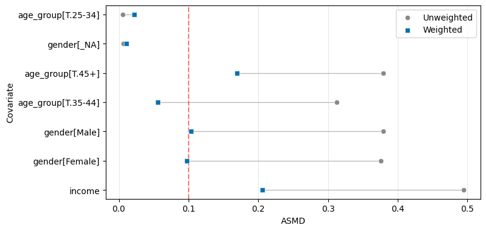

```python
# Static seaborn axes (publication-style figures)
adjusted.covars().love_plot(library="seaborn")
```

```python
# ASCII text (terminals / logs / LLM-friendly summaries)
print(adjusted.covars().love_plot(library="balance"))
```

```
Love plot (ASMD) - Threshold = 0.1
Covariate          | Unweighted |   Weighted | Change
------------------------------------------------------------------------------------------------------------
                   |            |            | 0       0.1      0.2     0.3     0.4      0.5   0.6
                   |            |            |         |
age_group[T.25-34] |   0.005688 |    0.02178 |  o*     |                                           (worse)
gender[_NA]        |   0.006296 |    0.01058 |  @      |                                           (worse)
age_group[T.45+]   |     0.3788 |     0.1698 |         |     *<----------------o                   (improved)
age_group[T.35-44] |     0.3127 |    0.05588 |      *<-!-----------------o                         (improved)
gender[Male]       |     0.3793 |      0.104 |         |*<---------------------o                   (improved)
gender[Female]     |     0.3757 |    0.09792 |         !<---------------------o                    (improved)
income             |     0.4942 |     0.2055 |         |        *<----------------------o          (improved)

Legend: o = unweighted, * = weighted, @ = overlap
        <----- improved (moving toward 0)
        -----> worse (moving away from 0)
        | = threshold, ! = threshold overlap
```

### Love plot options and `.plot()` shortcut

The same diagnostic can also be requested through the standard `.plot()` entrypoint with `dist_type="love_plot"` (or the `"love"` alias).

Useful options include:

- `library="plotly"` (default) for an interactive Plotly figure; `"seaborn"` for a static seaborn/matplotlib `Axes`; `"balance"` for a plain ASCII text summary suitable for terminals, logs, and LLM workflows.
- `line=True` to connect each covariate's before/after points.
- `order_by="diff"` (default; signed `after - before`, so regressions float to the top and improvements sink to the bottom), `"before"`, `"after"`, `"alphabetical"`, or `"none"` to control the variable ordering.

```python
# Equivalent dispatch via the .plot() entrypoint
adjusted.covars().plot(
    dist_type="love_plot",
)
```

[interactive chart not shown]

```python
# ASCII Love plot via the .plot() entrypoint
print(
    adjusted.covars().plot(
        dist_type="love_plot",
        library="balance",
    )
)
```

```
Love plot (ASMD) - Threshold = 0.1
Covariate          | Unweighted |   Weighted | Change
------------------------------------------------------------------------------------------------------------
                   |            |            | 0       0.1      0.2     0.3     0.4      0.5   0.6
                   |            |            |         |
age_group[T.25-34] |   0.005688 |    0.02178 |  o*     |                                           (worse)
gender[_NA]        |   0.006296 |    0.01058 |  @      |                                           (worse)
age_group[T.45+]   |     0.3788 |     0.1698 |         |     *<----------------o                   (improved)
age_group[T.35-44] |     0.3127 |    0.05588 |      *<-!-----------------o                         (improved)
gender[Male]       |     0.3793 |      0.104 |         |*<---------------------o                   (improved)
gender[Female]     |     0.3757 |    0.09792 |         !<---------------------o                    (improved)
income             |     0.4942 |     0.2055 |         |        *<----------------------o          (improved)

Legend: o = unweighted, * = weighted, @ = overlap
        <----- improved (moving toward 0)
        -----> worse (moving away from 0)
        | = threshold, ! = threshold overlap
```

## Density plots with seaborn (KDE)

The default `.covars().plot()` uses Plotly. You can also pass `library="seaborn"` together with `dist_type="kde"` to render seaborn-based kernel-density plots — useful for static publication-style figures or environments without a Plotly renderer.

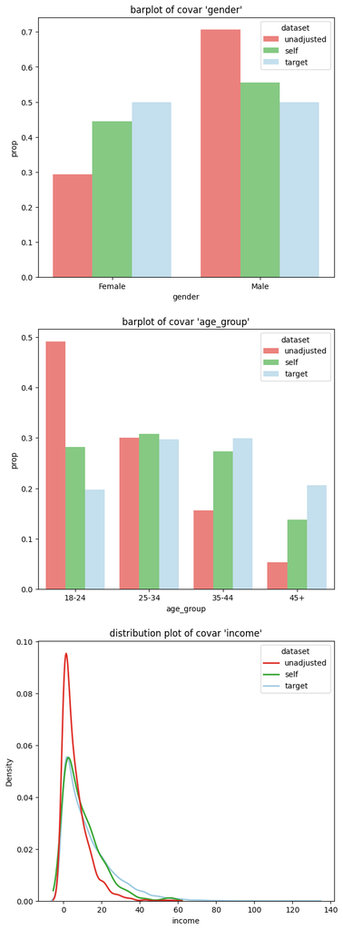

```python
# This shows how we could use seaborn to plot a kernel density estimation
adjusted.covars().plot(library = "seaborn", dist_type = "kde")
```

## ASCII Plot: Adjusted vs Unadjusted vs Target

You can use `library="balance"` with `.covars().plot()` to get a text-based comparison of unadjusted sample, adjusted sample, and target population. This is useful in terminals, logging contexts, or notebooks with limited rendering.

For more ASCII plot options (comparative histograms, category spacing, per-variable views), see the dedicated **`balance_ascii_plots`** tutorial.

```python
# ASCII plot comparing all three: unadjusted sample, adjusted sample, and target population
adjusted.covars().plot(library="balance", bar_width=30);
```

```
=== gender (categorical) ===

Category | population  adjusted  sample
Female   | █████████████████████ (50.0%)
         | ▒▒▒▒▒▒▒▒▒▒▒▒▒▒▒▒▒▒▒ (44.5%)
         | ▐▐▐▐▐▐▐▐▐▐▐▐ (29.4%)

Male     | █████████████████████ (50.0%)
         | ▒▒▒▒▒▒▒▒▒▒▒▒▒▒▒▒▒▒▒▒▒▒▒▒ (55.5%)
         | ▐▐▐▐▐▐▐▐▐▐▐▐▐▐▐▐▐▐▐▐▐▐▐▐▐▐▐▐▐▐ (70.6%)

Legend: █ population  ▒ adjusted  ▐ sample
Bar lengths are proportional to weighted frequency within each dataset.

=== age_group (categorical) ===

Category | population  adjusted  sample
18-24    | ████████████ (19.7%)
         | ▒▒▒▒▒▒▒▒▒▒▒▒▒▒▒▒▒ (28.1%)
         | ▐▐▐▐▐▐▐▐▐▐▐▐▐▐▐▐▐▐▐▐▐▐▐▐▐▐▐▐▐▐ (49.1%)

25-34    | ██████████████████ (29.7%)
         | ▒▒▒▒▒▒▒▒▒▒▒▒▒▒▒▒▒▒▒ (30.7%)
         | ▐▐▐▐▐▐▐▐▐▐▐▐▐▐▐▐▐▐ (30.0%)

35-44    | ██████████████████ (29.9%)
         | ▒▒▒▒▒▒▒▒▒▒▒▒▒▒▒▒▒ (27.4%)
         | ▐▐▐▐▐▐▐▐▐▐ (15.6%)

45+      | █████████████ (20.6%)
         | ▒▒▒▒▒▒▒▒ (13.8%)
         | ▐▐▐ (5.3%)

Legend: █ population  ▒ adjusted  ▐ sample
Bar lengths are proportional to weighted frequency within each dataset.

=== income (numeric, comparative) ===

Range            | population (%)            | adjusted (%)                | sample (%)
----------------------------------------------------------------------------------------------------------------
[0.00, 8.57)     | ████████████████████ 49.0 | ████████████████████▒▒ 54.8 | ████████████████████▒▒▒▒▒▒▒▒▒▒ 73.2
[8.57, 17.14)    | █████████ 23.1            | █████████▒▒ 26.3            | ████████] 19.2
[17.14, 25.71)   | █████ 13.2                | █████ 12.3                  | ██  ] 5.3
[25.71, 34.28)   | ███ 7.3                   | ██] 3.9                     | █ ] 1.6
[34.28, 42.85)   | ██ 3.9                    | █] 1.5                      |  ] 0.4
[42.85, 51.41)   | █ 1.8                     | ] 0.2                       | ] 0.1
[51.41, 59.98)   | 0.9                       | 1.0                         | 0.2
[59.98, 68.55)   | 0.4                       | 0.0                         | 0.0
[68.55, 77.12)   | 0.2                       | 0.0                         | 0.0
[77.12, 85.69)   | 0.1                       | 0.0                         | 0.0
[85.69, 94.26)   | 0.0                       | 0.0                         | 0.0
[94.26, 102.83)  | 0.0                       | 0.0                         | 0.0
[102.83, 111.40) | 0.0                       | 0.0                         | 0.0
[111.40, 119.97) | 0.0                       | 0.0                         | 0.0
[119.97, 128.54] | 0.0                       | 0.0                         | 0.0
----------------------------------------------------------------------------------------------------------------
Total            | 100.0                     | 100.0                       | 100.0

Key: █ = shared with population, ▒ = excess,    ] = deficit
```